# Module 6 Peer Review Assignment

# Problem 1

Suppose $X$ and $Y$ are independent normal random variables with the same mean $\mu$ and the same variance $\sigma^2$. Do the random variables $W = X + Y$ and $U=2X$ have the same distribution? Explain.

No, the distributions will have the same mean but the variances will be different. W will have $Mean = E[X] + E[Y] = \mu + \mu = 2\mu$ and U will have $Mean = E[2X] = 2 * E[X] = 2 * \mu = 2\mu$. The variance of W will simply be $Var(W) = Var(X) + Var(Y) = \sigma^2 + \sigma^2 = 2\sigma^2$, but the variance of U will be $Var(W) = Var(2X) = 4 * Var(X) = 4 * \sigma^2 = 4\sigma^2$.

# Problem 2: Central Limit Theorem and Simulation

**a)** For this problem, we will be sampling from the Uniform distribution with bounds [0, 100]. Before we simulate anything, let's make sure we understand what values to expect. If $X \sim U(0, 100)$, what is $E[X]$ and $Var(X)$?

For a random variable $X$ ~ $Unif(0, 100)$:
$$E[X] = \frac{b - a}{2} = \frac{100 - 0}{2} = 50$$
$$Var(X) = \frac{(b - a)^2}{12} = \frac{(100 - 0)^2}{12} = \frac{2500}{3}$$

**b)** In real life, if we want to estimate the mean of a population, we have to draw a sample from that population and compute the sample mean. The important questions we have to ask are things like:

- Is the sample mean a good approximation of the population mean?
- How large does my sample need to be in order for the sample mean to well-approximate the population mean?

Complete the following function to sample $n$ rows from the $U(0, 100)$ distribution and return the sample mean. Start with a sample size of 10 and draw a sample mean from your function. Is the estimated mean a good approximation for the population mean we computed above? What if you increase the sample size?

```r
uniform.sample.mean = function(n){

    #set.seed(123)
    sample.mean <- mean(runif(n, min=0, max=100))
    return(sample.mean)
}

uniform.sample.mean(10)
uniform.sample.mean(1000)
uniform.sample.mean(500000)
```

51.9195414055139

50.4836439696839

50.0047665043357

The $n=10$ estimated mean is a poor approximation for the population mean because the standard deviation and variance are much too high with only 10 samples. For repeated trials of 10 samples we would expect to have estimated means greater than 60 and less than 40 frequently. Increasing the sample size will drive down the variance on the sample mean and give a more accurate result compared to the true population mean because sample size is inversely proportional to sample mean standard deviation. As the Law of Large Numbers predicts, our sample mean estimate of the true population mean approaches the theoretical value of 50 as we increase the number of trials.

**c)** Notice, for a sample size of $n$, our function is returning an estimator of the form

$$ \bar{X} = \frac{1}{n}\sum_{i=1}^n X_i $$

That means, if each $X_i$ is a random variable, then our sample mean is also a random variable with its own distribution. We call this disribution the sample distribution. Let's take a look at what this distribution looks like.

Using the `uniform.sample.mean` function, simulate $m=1000$ sample means, each from a sample of size $n=10$. Create a histogram of these sample means. Then increase the value of $n$ and plot the histogram of those sample means. What do you notice about the distribution of $\bar{X}$? What is the mean $\mu$ and variance $\sigma^2$ of the sample distribution?

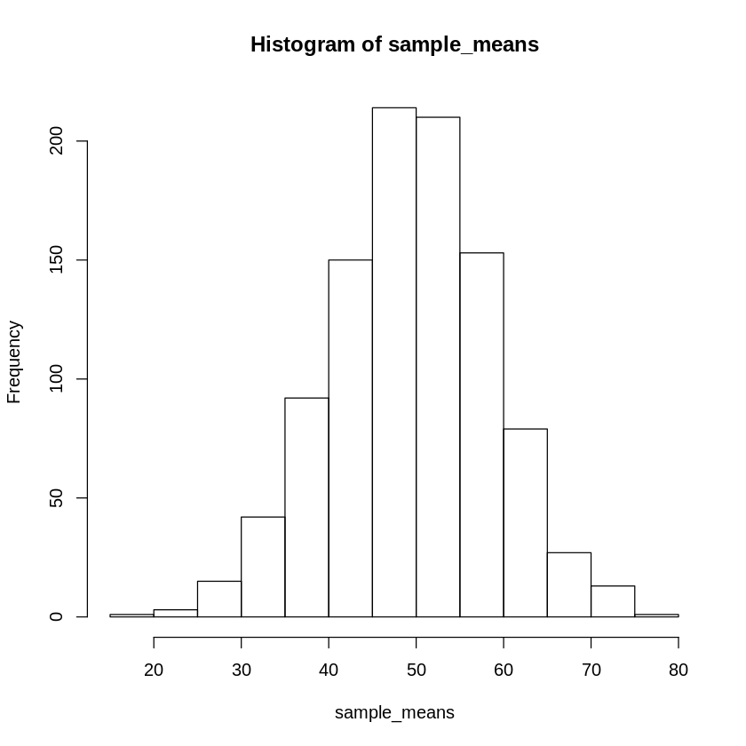

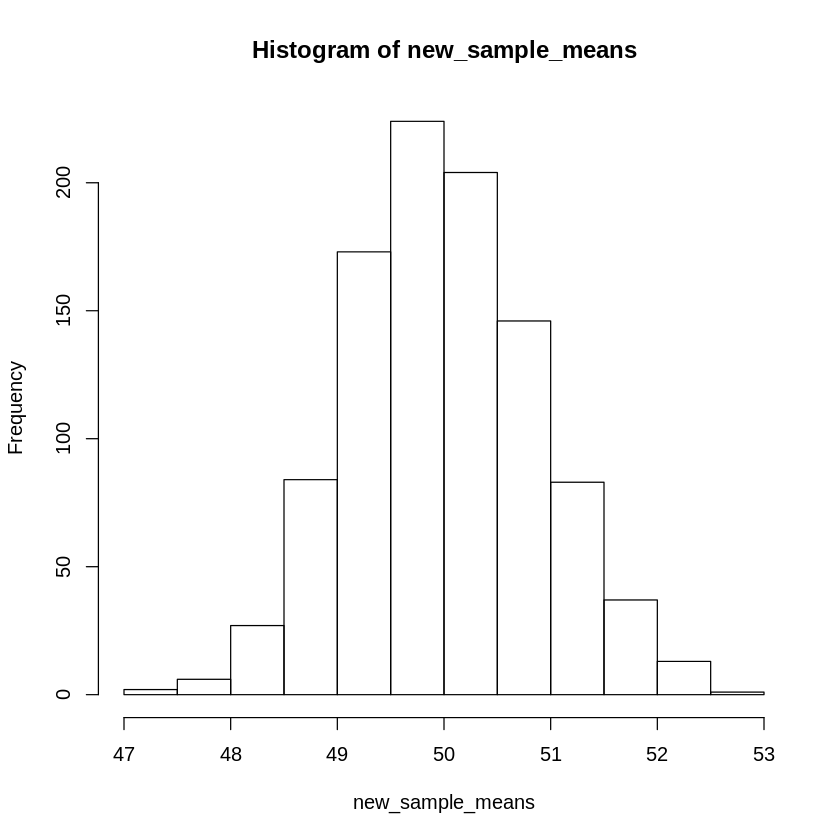

```r
n <- 10
sample_means <- rep(NA, 1000)
for (x in 1:1000) {
    sample_means[x] = uniform.sample.mean(n)
}
#sample_means
hist(sample_means)

new_n <- 1000
new_sample_means <- rep(NA, 1000)
for (x in 1:1000) {
    new_sample_means[x] = uniform.sample.mean(new_n)
}
#new_sample_means
hist(new_sample_means)
```

**d)** Recall that our underlying population distribution is $U(0, 100)$. Try changing the underlying distribution (For example a binomial(10, 0.5)) and check the sample distribution. Be sure to explain what you notice.

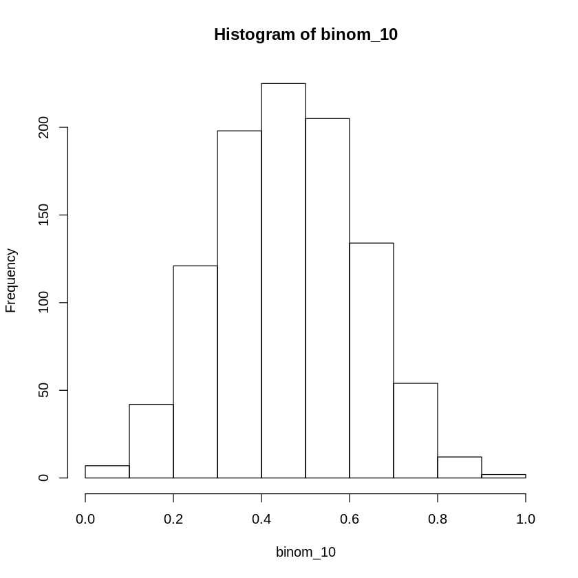

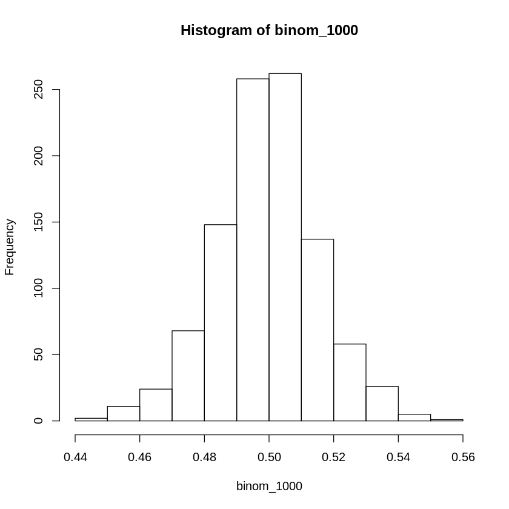

```r
binom.sample.mean = function(n) {
    sample.mean = mean(rbinom(n, size=1, prob=0.5))
}

binom_10 = rep(NA, 1000)
binom_1000 = rep(NA, 1000)

for (i in 1:1000) {
    binom_10[i] = binom.sample.mean(10)
}
hist(binom_10)

for (i in 1:1000) {
    binom_1000[i] = binom.sample.mean(1000)
}
hist(binom_1000)
```

As in part c, the sample means from the new binomial distribution are normally distributed regardless of the number of trials. This is because regardless of what the initial distribution is, by plotting enough sample means of the distribution the result will be normally distributed by the Central Limit Theorem. Again, the mean remains constant with the number of samples and the variance decreases linearly with sample size.

# Problem 3

Let $X$ be a random variable for the face value of a fair $d$-sided die after a single roll. $X$ follows a discrete uniform distribution of the form $\textrm{unif}\{1,d\}$. Below is the mean and variance of $\textrm{unif}\{1,d\}$.

$$ E[X] = \dfrac{1+d}{2} \qquad Var(X) = \dfrac{(d- 1 + 1)^2 - 1}{12}$$

**a)** Let $\bar{X}_n$ be the random variable for the mean of $n$ die rolls. Based on the Central Limit Theorem, what distribution does $\bar{X}_n$ follow when $d=6$.

$\bar{X}_n$ would follow a normal distribution if n was sufficiently large enough to apply the CLT. The expectation value would be $E[\bar{X_n}] = \frac{1 + 2 + 3 + 4 + 5 + 6}{6} = 3.5$ and the variance would be $Var(\bar{X}) = \frac{(6 - 1 + 1)^2 - 1}{12} = \frac{35}{12}$, or $\bar{X}$ ~ $N(3.5, \frac{35}{12})$ and thus $\bar{X_n}$ ~ $N(3.5, \frac{35}{12n})$.

**b)** Generate $n=1000$ die values, with $d=6$. Calculate the running average of your die rolls. In other words, create an array $r$ such that:

$$ r[j] = \sum_{i=1}^j \dfrac{X_i}{j} $$

Finally, plot your running average per the number of iterations. What do you notice?

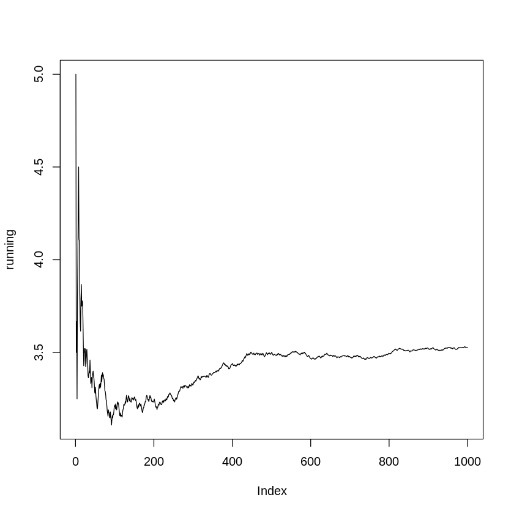

```r
#d <- 6
#a <- 1

die = sample(1:6, size=1000, replace=TRUE)
running <- rep(NA, 1000)
total <- 0

# uniform.sample.mean.generic = function(n, a, b){

#     #set.seed(123)
#     sample.mean <- mean(runif(n, min=a, max=b))
#     return(sample.mean)
# }

for (x in 1:1000) {
    #temp = uniform.sample.mean.generic(n, a, d)
    #temp = die[x]
    total = total + die[x]
    running[x] = total / x

}

plot(running, type='l')
```

Early on in the running average, there is a considerable amount of fluctuation in the value, i.e. there is high variability due to the small number of samples. As more and more samples are acquired, the variance decreases and the running average tapers off at approximately 3.5, which is the theoretically expected value for a single fair die roll. We would expect to see this behavior of the estimated mean approaching the true mean because of the Law of Large Numbers and the Central Limit Theorem.